# Anexo

## Parametros

Realizamos una regresión entre nuestras variables “Goles totales por mundial” y “Asistencia total por mundial”, obteniendo:

```r
summary(regresion)
```

```
##
## Call:
## lm(formula = goles ~ AsisTotal)
##
## Residuals:
##     Min      1Q  Median      3Q     Max
## -23.943 -17.906  -7.308  19.929  44.079
##
## Coefficients:
##              Estimate Std. Error t value Pr(>|t|)
## (Intercept) 7.202e+01  9.814e+00   7.339 5.89e-07 ***
## AsisTotal   2.534e-05  4.450e-06   5.695 1.73e-05 ***
## ---
## Signif. codes:  0 '***' 0.001 '**' 0.01 '*' 0.05 '.' 0.1 ' ' 1
##
## Residual standard error: 21.17 on 19 degrees of freedom
## Multiple R-squared:  0.6306, Adjusted R-squared:  0.6111
## F-statistic: 32.43 on 1 and 19 DF,  p-value: 1.726e-05
```

Podemos notar que nuestro intercepto y nuestra pendiente son significativos, para corroborarlo evaluamos su valor t.

```r
intercepto_valort > qt(0.95,19)
```

```
## [1] TRUE
```

```r
pendiente_valort > qt(0.95,19)
```

```
## [1] TRUE
```

Como ambos son mayores al cuantil 95 de la distribucion t, ambos son significativos.

## Residuos

### Gráfico Residuos vs Valores ajustados

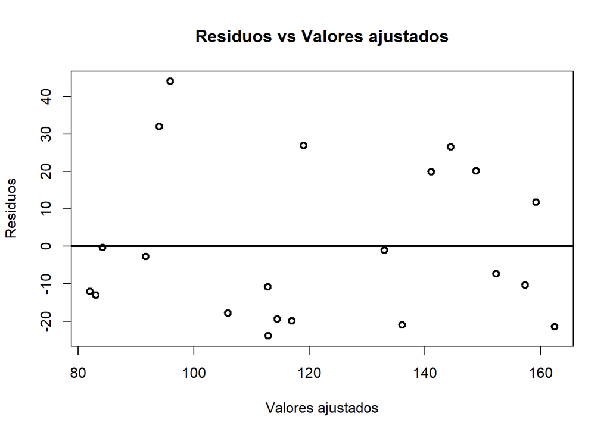

```r
plot(fitted(regresion), resid(regresion),
     xlab = "Valores ajustados",
     ylab = "Residuos",
     main = "Residuos vs Valores ajustados",
     lwd = 2 )
abline(h = 0, lwd = 2)
```

### Gráfico Residuos vs Predictor

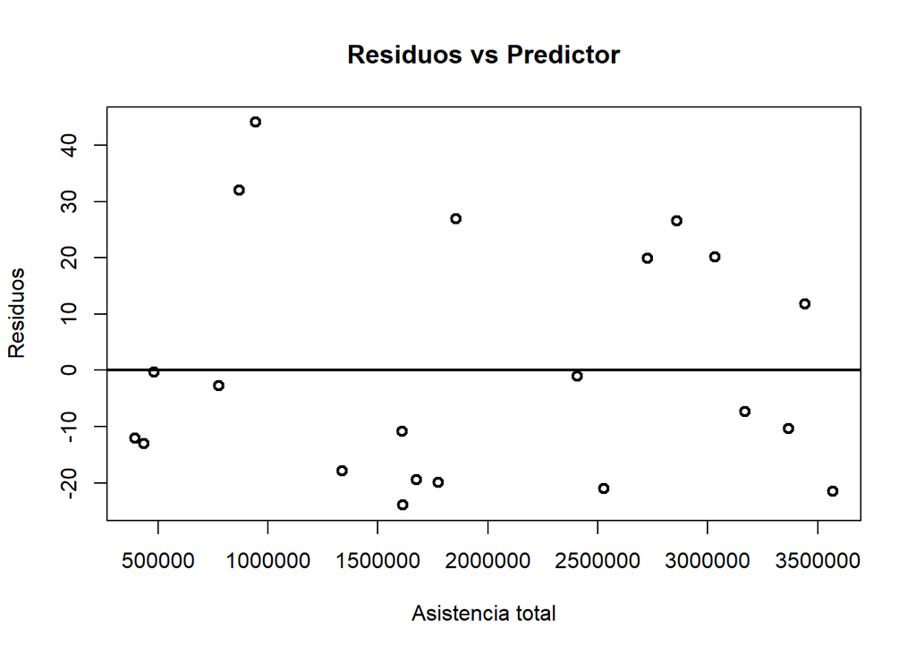

```r
plot(AsisTotal, resid(regresion),
     xlab = "Asistencia total",
     ylab = "Residuos",
     main = "Residuos vs Predictor",
     lwd = 2)
abline(h = 0, lwd = 2)
```

Podemos notar en ambos graficos que los residuos de nuestra regresión no siguen ningun patrón.

## Outliers

### Residuos estudentizados

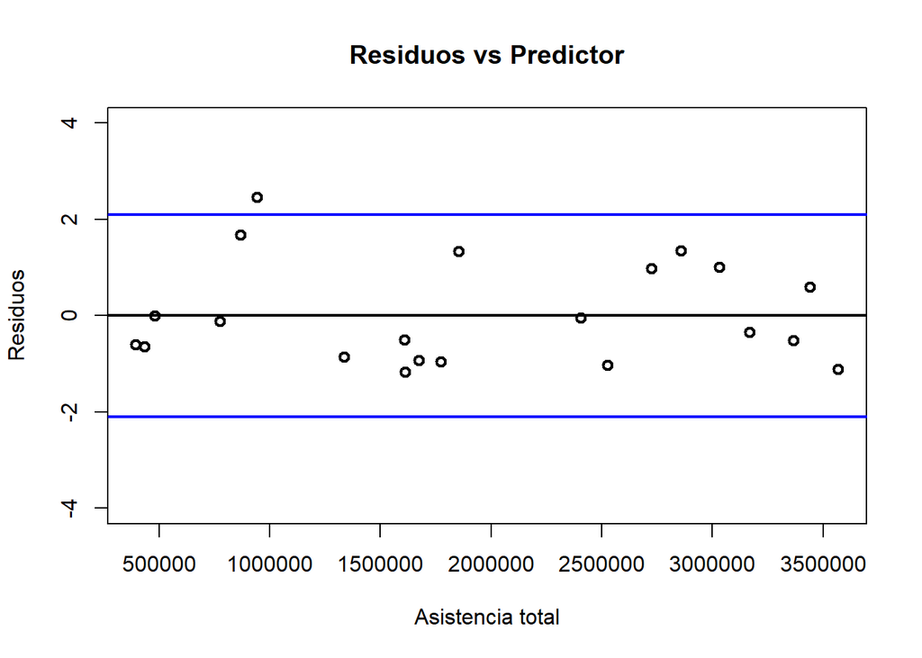

```r
plot(AsisTotal, rstudent(regresion),
     xlab = "Asistencia total",
     ylab = "Residuos",
     main = "Residuos vs Predictor",
     lwd = 2,
     ylim = c(-4,4))
abline(h = 0, lwd = 2)

abline(h = qt(0.975, n - 3), col = "blue", lwd = 2)
abline(h = -qt(0.975, (n - 3)), col = "blue", lwd = 2)
```

### Residuos estandarizados

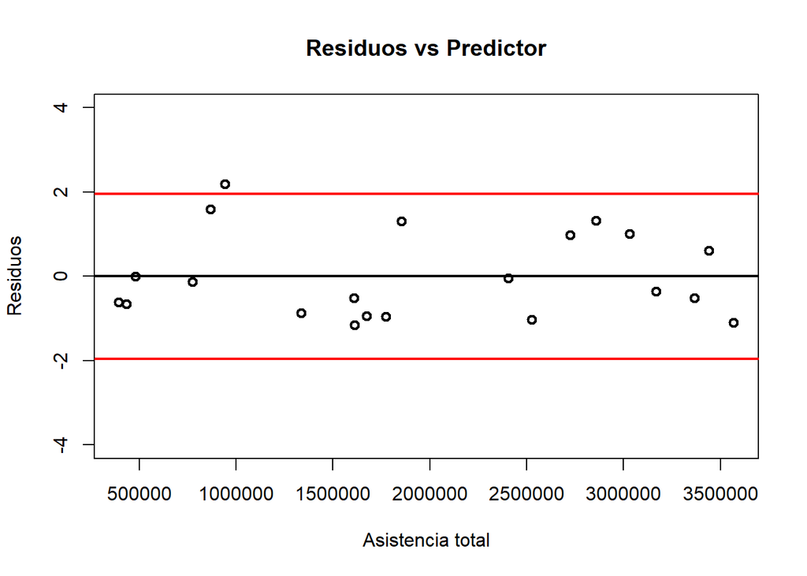

```r
plot(AsisTotal, rstandard(regresion),
     xlab = "Asistencia total",
     ylab = "Residuos",
     main = "Residuos vs Predictor",
     lwd = 2,
     ylim = c(-4,4))
abline(h = 0, lwd = 2)

abline(h = qnorm(0.975), col = "red", lwd = 2)
abline(h = -qnorm(0.975), col = "red", lwd = 2)
```

Podemos observar un solo residuo que es outlier, el resto esta dentro de los límites.

Realizando el test de normalidad:

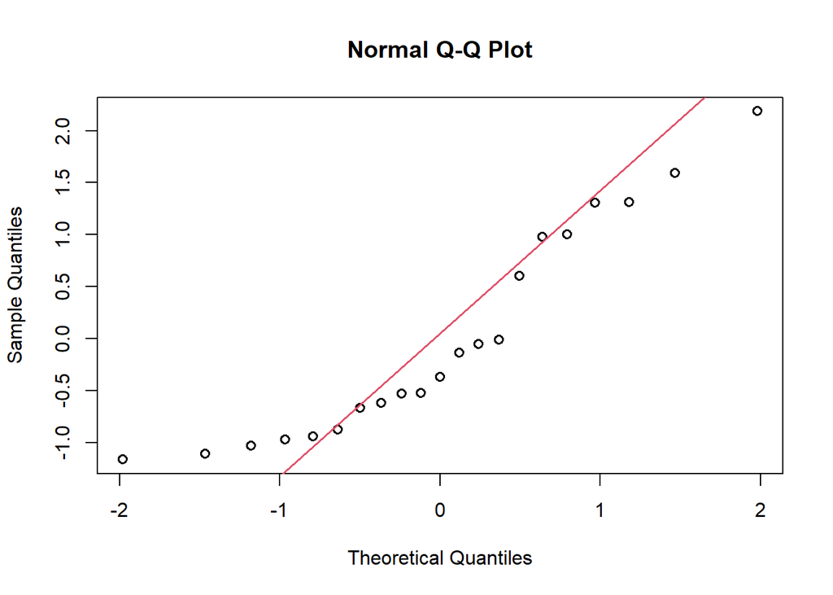

```r
qqnorm(rstandard(regresion), lwd = 1.5)
qqline(rstandard(regresion), col = 2, lwd = 1.5)
```

A traves del gráfico podemos concluir que los residuos no se ajustan a la recta, es posible que el valor outlier este afectando a la regresion.

```r
outlier = which(qnorm(0.975) < rstandard(regresion))
```

El dato que se excede por arriba de la cota es el #17

Buscaremos los puntos influyentes.

```r
influyentes = as_tibble(influence.measures(regresion)$infmat)

gt(influyentes)
```

| dfb.1_ | dfb.AssT | dffit | cov.r | cook.d | hat |
| --- | --- | --- | --- | --- | --- |
| -0.1044063476 | 0.241415250 | 0.333944927 | 1.1100447 | 5.574061e-02 | 0.09974923 |
| -0.1118029245 | 0.201196318 | 0.244896953 | 1.2562000 | 3.105047e-02 | 0.14649880 |
| 0.0471828452 | -0.097765910 | -0.128263495 | 1.2393264 | 8.621294e-03 | 0.11364660 |
| 0.0894054819 | -0.166001951 | -0.205558528 | 1.2535462 | 2.197565e-02 | 0.13690001 |
| -0.0424357747 | 0.166371483 | 0.277200113 | 1.0854915 | 3.851009e-02 | 0.07443065 |
| -0.0931944127 | 0.268176095 | 0.405923080 | 1.0073240 | 7.911722e-02 | 0.08450109 |
| 0.2420613018 | -0.416431185 | -0.494325657 | 1.1658849 | 1.206207e-01 | 0.16402042 |
| 0.0055044802 | -0.130059613 | -0.266071210 | 1.0599675 | 3.528431e-02 | 0.06256939 |
| -0.0008600934 | -0.004890697 | -0.012034215 | 1.1812812 | 7.642384e-05 | 0.05703976 |
| 0.1626682356 | -0.025651542 | 0.298632302 | 0.9701817 | 4.285433e-02 | 0.04797300 |
| -0.0873424985 | 0.037354450 | -0.121436092 | 1.1420956 | 7.669807e-03 | 0.05259573 |
| -0.1333293121 | 0.035775489 | -0.219154411 | 1.0588163 | 2.409842e-02 | 0.04892276 |
| -0.1477616601 | 0.055140049 | -0.217676928 | 1.0666168 | 2.383739e-02 | 0.05088411 |
| -0.1978648362 | 0.083918214 | -0.276141693 | 1.0146814 | 3.738493e-02 | 0.05246425 |
| -0.0443336851 | 0.034104409 | -0.045594556 | 1.2468640 | 1.096134e-03 | 0.10810068 |
| 0.5305617595 | -0.397249163 | 0.551516311 | 0.9287810 | 1.391282e-01 | 0.09896123 |
| 0.7449741899 | -0.543978746 | 0.782915867 | 0.6877070 | 2.421751e-01 | 0.09206421 |
| -0.1936227472 | 0.114923343 | -0.227161045 | 1.0965070 | 2.613855e-02 | 0.06399947 |
| -0.0052737030 | 0.004335903 | -0.005316579 | 1.2988674 | 1.491803e-05 | 0.14219386 |
| -0.2579010944 | 0.215395892 | -0.259190617 | 1.2644701 | 3.474319e-02 | 0.15391540 |
| -0.2728566303 | 0.226330166 | -0.274570101 | 1.2479897 | 3.885587e-02 | 0.14856935 |

### Distancia de Cook

```r
which(influyentes$cook.d > qf(0.975,df1 = 1,df2 = n-2))
```

```
## integer(0)
```

Ningun punto es influyente para la distancia de cook.

### DFBETAS

```r
which(abs(influyentes$dfb.1_) > 2/sqrt(n))
```

```
## [1] 16 17
```

Los puntos 16 y 17 son influyentes para DFBETAS.

### DFFITS

```r
which(abs(influyentes$dfb.1_) > 2*sqrt(2/n))
```

```
## [1] 17
```

El punto 17 es influyente para DFFITS.

### COVRATIO

```r
influyentes1 = which(abs(influyentes$cov.r) > 1 + 3 * 2/n)

influyentes2 = which(abs(influyentes$cov.r) < 1 - 3 * 2/n)
```

Los puntos 19 y 17 son influyentes para COVRATIO.

Luego de realizar estos cuatro tests podemos concluir que efectivamente el dato #17 afecta negativamente al calculo de la regresion. Una buena medida seria eliminar ese dato del analisis, para asi obtener una mejor recta de regresión.

Realizando el test de normalidad:

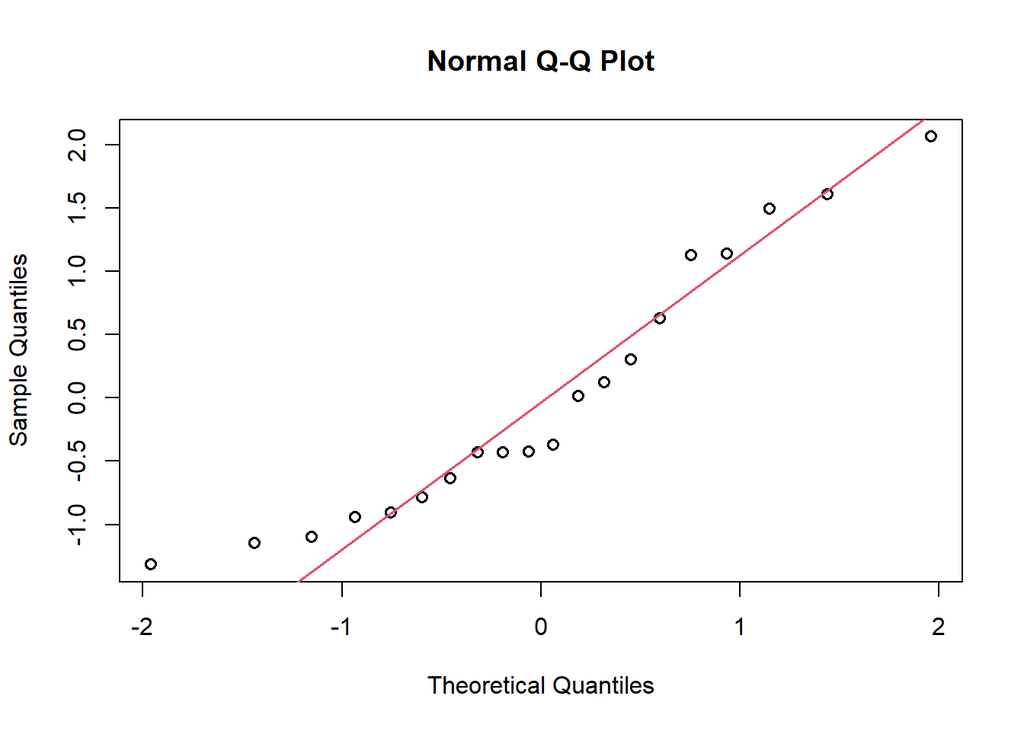

```r
qqnorm(rstandard(regresion_nueva), lwd = 1.5)
qqline(rstandard(regresion_nueva), col = 2, lwd = 1.5)
```

A traves del gráfico podemos concluir que los residuos se ajustan a la recta de mejor manera luego de eliminar el dato outlier.